# Lecture 14: Model Building

Joong-Ho Won @ SNU

August 31, 2018

# Model building

- We focus on real data.
- You will learn how you can progressively build up a model to aid your understanding of the data.

### Prerequisites

```r
library(tidyverse)
library(modelr)
options(na.action = na.warn)

library(nycflights13)
library(lubridate)
```

## Why are low quality diamonds more expensive?

In Lecture 4 we’ve seen a surprising relationship between the quality of diamonds and their price: low quality diamonds (poor cuts, bad colours, and inferior clarity) have higher prices!

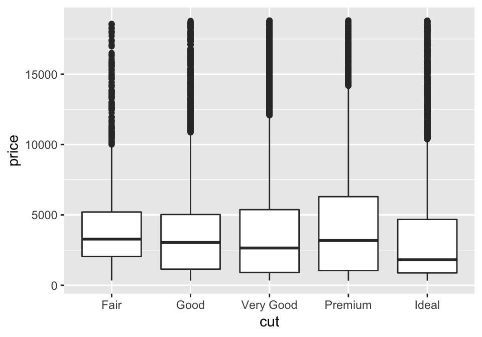

```r
ggplot(diamonds, aes(cut, price)) + geom_boxplot()
```

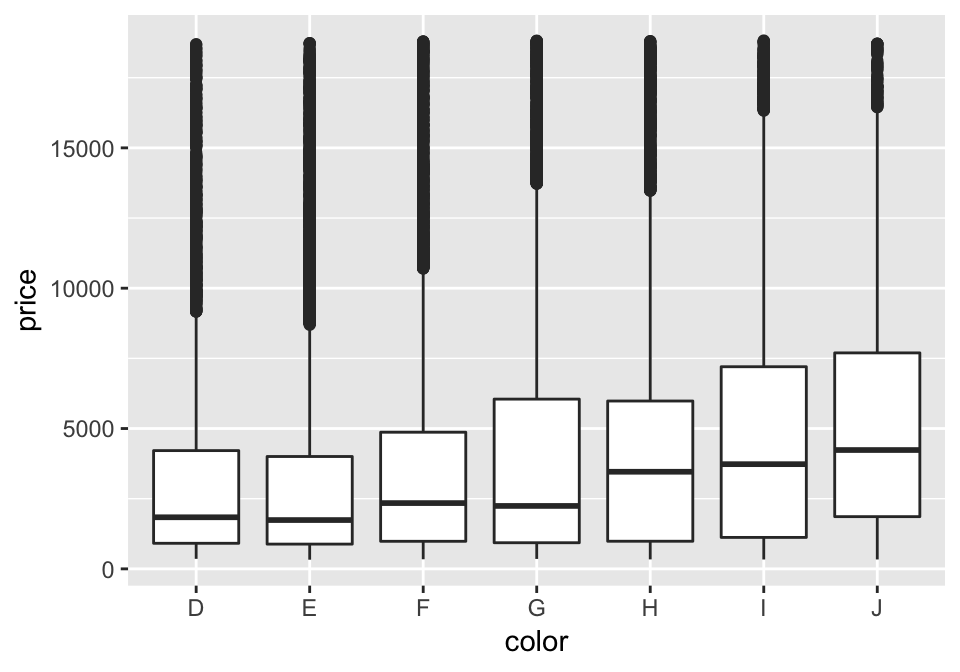

```r
ggplot(diamonds, aes(color, price)) + geom_boxplot()
```

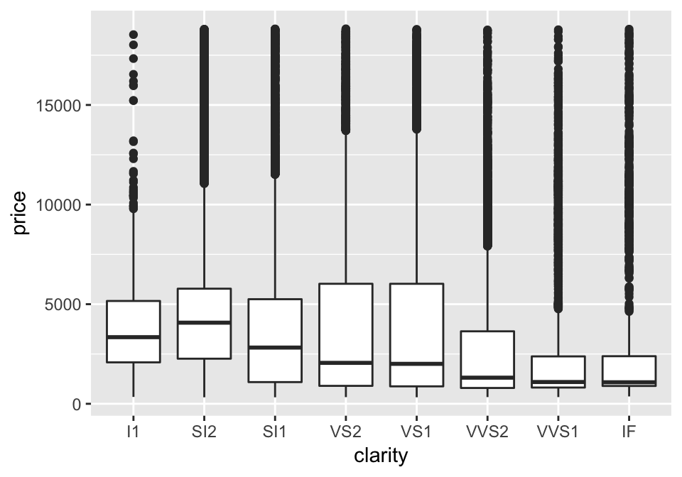

```r
ggplot(diamonds, aes(clarity, price)) + geom_boxplot()
```

The worst diamond color is J, and the worst clarity is I1.

### Price and carat

#### Confounding

> In statistics, a confounder (also confounding variable, confounding factor or lurking variable) is a variable that influences both the dependent variable and independent variable causing a spurious association.

> [Wikipedia](https://en.wikipedia.org/wiki/Confounding)

What would be the single most important factor for determining the price of the diamond?

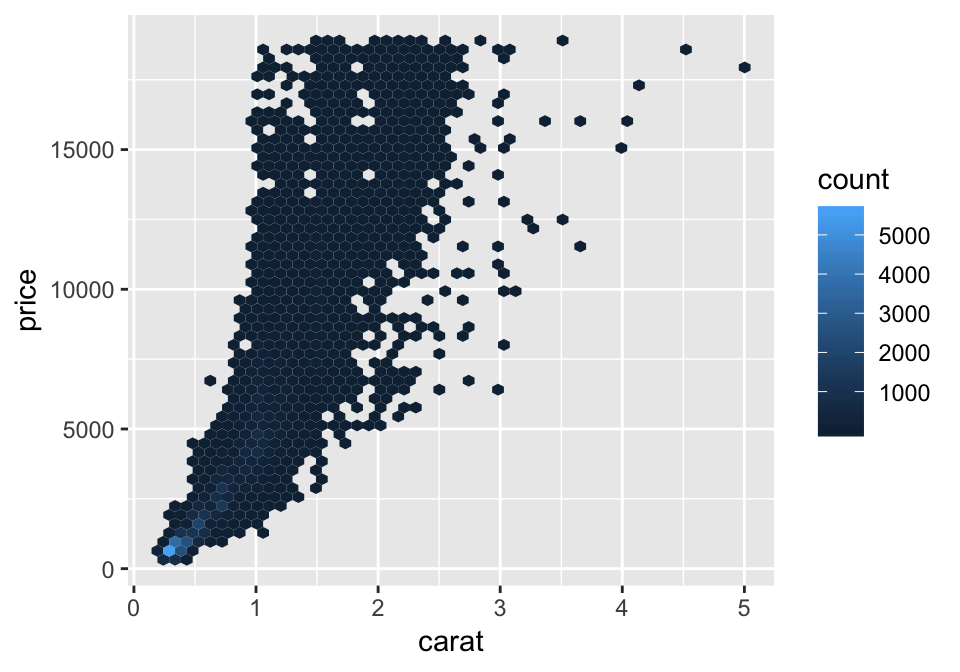

```r
ggplot(diamonds, aes(carat, price)) +
  geom_hex(bins = 50)
```

Lower quality diamonds tend to be larger.

We can make it easier to see how the other attributes of a diamond affect its relative `price` by fitting a model to separate out the effect of `carat`.

Some tweaks to the diamonds dataset for clarity:

1. Focus on diamonds smaller than 2.5 carats (99.7% of the data)
2. Log-transform the carat and price variables.

```r
diamonds2 <- diamonds %>%
  filter(carat <= 2.5) %>%
  mutate(lprice = log2(price), lcarat = log2(carat))
```

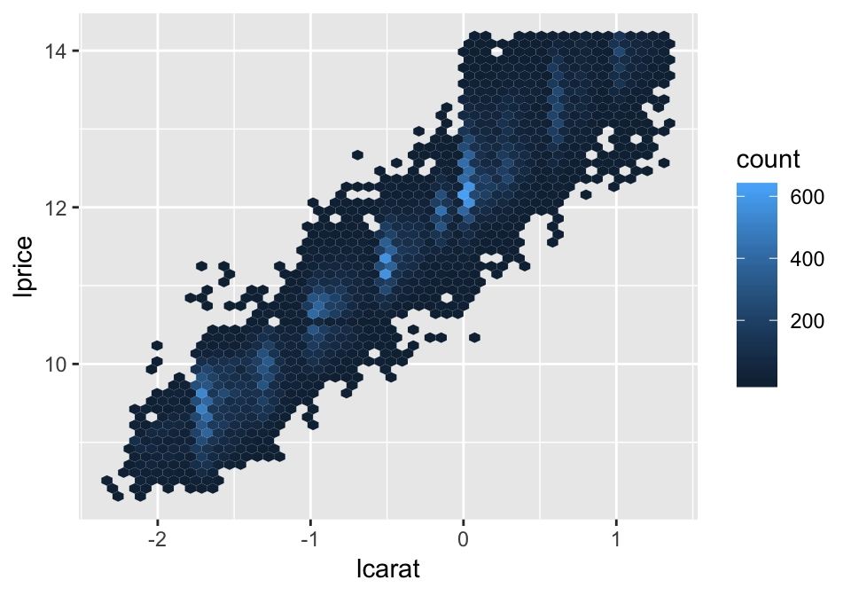

```r
ggplot(diamonds2, aes(lcarat, lprice)) +
  geom_hex(bins = 50)
```

The log-transformation makes the pattern linear

Remove the strong linear pattern:

```r
mod_diamond <- lm(lprice ~ lcarat, data = diamonds2)
```

Visualise the fitted model after undoing the log transformation:

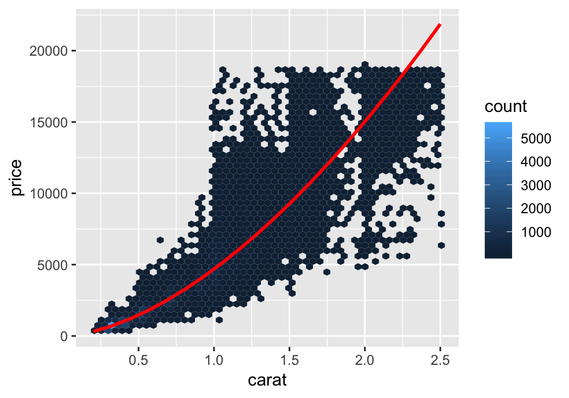

```r
grid <- diamonds2 %>%
  data_grid(carat = seq_range(carat, 20)) %>%
  mutate(lcarat = log2(carat)) %>%
  add_predictions(mod_diamond, "lprice") %>%
  mutate(price = 2 ^ lprice)

ggplot(diamonds2, aes(carat, price)) +
  geom_hex(bins = 50) +
  geom_line(data = grid, colour = "red", size = 1)
```

Now look at the residuals to see if we’ve successfully removed the strong linear pattern:

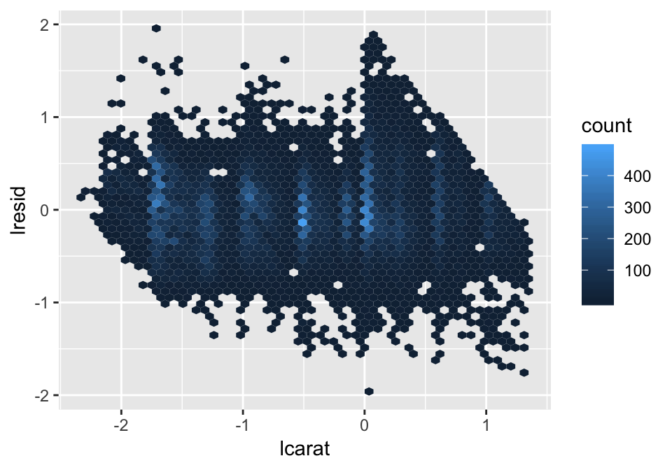

```r
diamonds2 <- diamonds2 %>%
  add_residuals(mod_diamond, "lresid")

ggplot(diamonds2, aes(lcarat, lresid)) +
  geom_hex(bins = 50)
```

Re-do our motivating plots using those **residuals** instead of `price`:

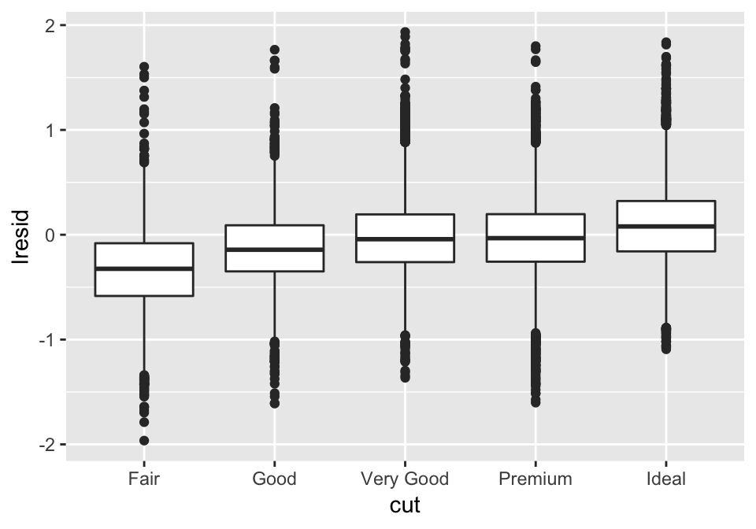

```r
ggplot(diamonds2, aes(cut, lresid)) + geom_boxplot()
```

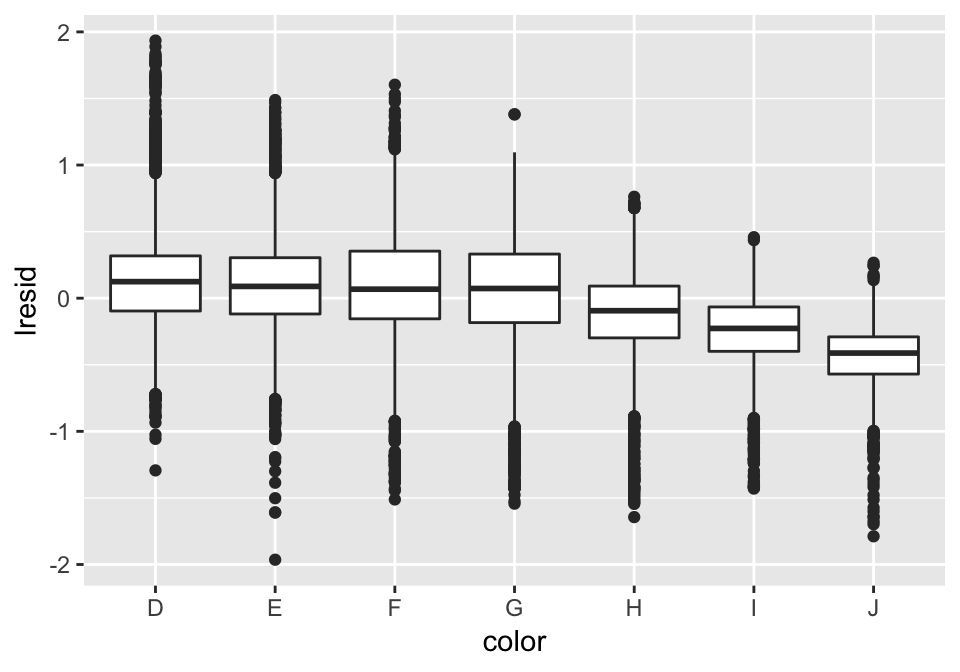

```r
ggplot(diamonds2, aes(color, lresid)) + geom_boxplot()
```

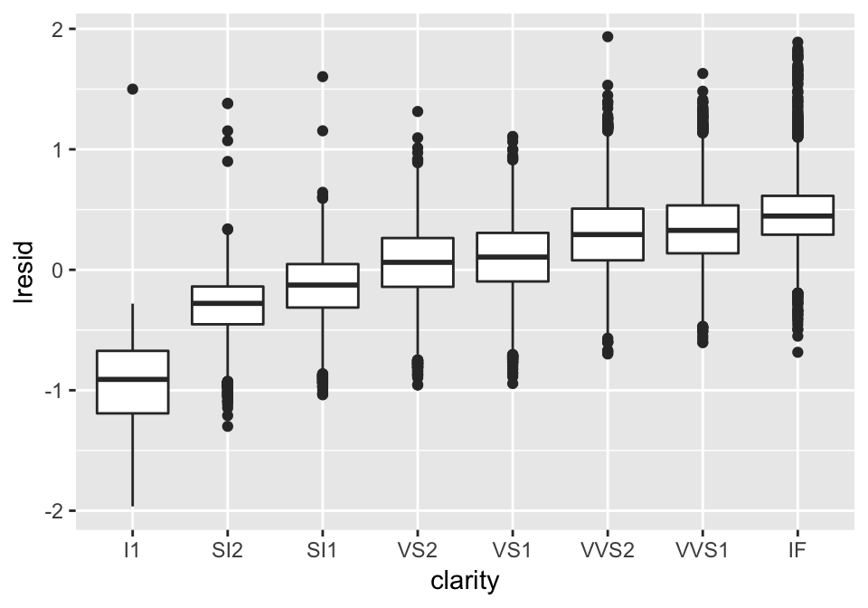

```r
ggplot(diamonds2, aes(clarity, lresid)) + geom_boxplot()
```

Now, as the quality of the diamond increases, so too does its relative price, as expected.

#### Interpreting the `y` axis

- A residual of -1 indicates that `lprice` was 1 unit lower than a prediction based solely on its weight.
- Points with a value of -1 are half the expected price (we used `log2()`), and residuals with value 1 are twice the predicted price.

### A more complicated model

```r
mod_diamond2 <- lm(lprice ~ lcarat + color + cut + clarity, data = diamonds2)
```

```r
grid <- diamonds2 %>%
  data_grid(cut, .model = mod_diamond2) %>%
  add_predictions(mod_diamond2)
grid
```

```
## # A tibble: 5 x 5
##   cut       lcarat color clarity  pred
##   <ord>      <dbl> <chr> <chr>   <dbl>
## 1 Fair      -0.515 G     VS2      11.2
## 2 Good      -0.515 G     VS2      11.3
## 3 Very Good -0.515 G     VS2      11.4
## 4 Premium   -0.515 G     VS2      11.4
## 5 Ideal     -0.515 G     VS2      11.4
```

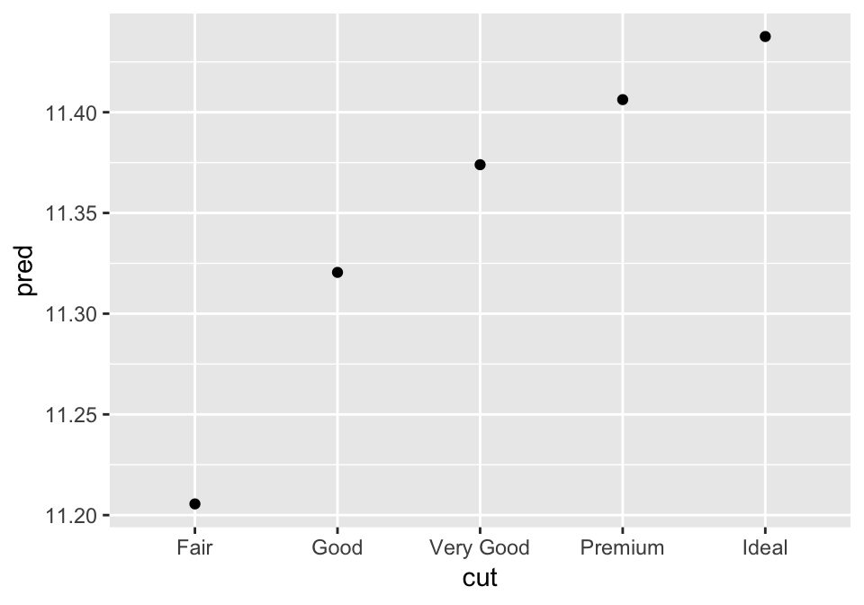

```r
ggplot(grid, aes(cut, pred)) +
  geom_point()
```

```r
grid <- diamonds2 %>%
  data_grid(color, .model = mod_diamond2) %>%
  add_predictions(mod_diamond2)
grid
```

```
## # A tibble: 7 x 5
##   color lcarat cut     clarity  pred
##   <ord>  <dbl> <chr>   <chr>   <dbl>
## 1 D     -0.515 Premium VS2      11.6
## 2 E     -0.515 Premium VS2      11.6
## 3 F     -0.515 Premium VS2      11.5
## 4 G     -0.515 Premium VS2      11.4
## 5 H     -0.515 Premium VS2      11.3
## 6 I     -0.515 Premium VS2      11.1
## 7 J     -0.515 Premium VS2      10.9
```

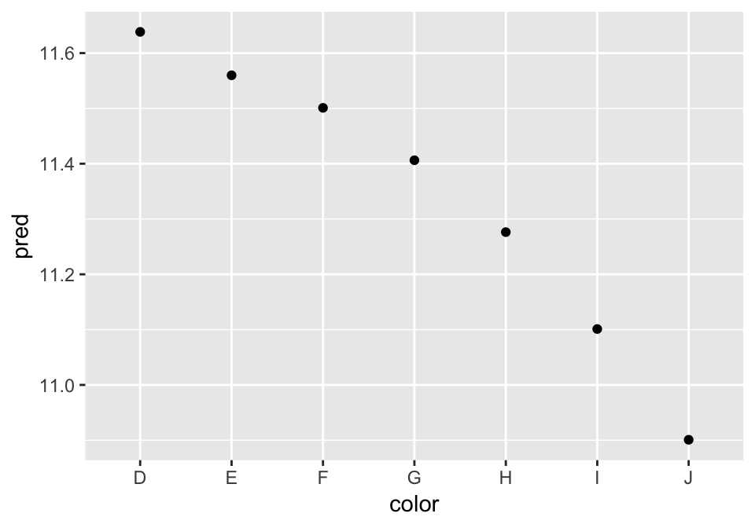

```r
ggplot(grid, aes(color, pred)) +
  geom_point()
```